# BIA 6301 APPLIED DATA MINING HOMEWORK ASSIGNMENT 1

Leonardo Ji

2017-03-21

## Part A. Underwriting at KC Health

The purpose of this assignment is to simulate underwriting at a health insurance company called KC Health.

You were recently hired as a data scientist in the underwriting team at KC Health. The Vice President of Underwriting, who is a Fellow of the Society of Actuaries, gave you two data files during your first week on the job. The first data file is named Insurance.csv, which contains last year’s medical charges of 1,338 customers. The data file also contains information of six demographic and geographic variables: age, sex, BMI, children, smoker, and region.

### Data

- **Age**: age of the customer
- **Sex**: sex of the customer
- **BMI**: reported body mass index (BMI) of customer
- **Children**: number of children reported by the customer
- **Smoker**: whether the customer is a smoker
- **Region**: region of the country where the customer resides. Four regions are included: northeast, northwest, southeast, and southwest.

```r
insuranceData<-read.csv(file="C:/Users/lj015625/Desktop/DataMining Class/Applied_Data_Mining/assignment_module_1/data/insurance.csv")
str(insuranceData)
```

```
## 'data.frame':    1338 obs. of  7 variables:
##  $ age     : int  19 18 28 33 32 31 46 37 37 60 ...
##  $ sex     : Factor w/ 2 levels "female","male": 1 2 2 2 2 1 1 1 2 1 ...
##  $ bmi     : num  27.9 33.8 33 22.7 28.9 ...
##  $ children: int  0 1 3 0 0 0 1 3 2 0 ...
##  $ smoker  : Factor w/ 2 levels "no","yes": 2 1 1 1 1 1 1 1 1 1 ...
##  $ region  : Factor w/ 4 levels "northeast","northwest",..: 4 3 3 2 2 3 3 2 1 2 ...
##  $ charges : num  16885 1726 4449 21984 3867 ...
```

```r
summary(insuranceData)
```

```
##       age            sex           bmi           children     smoker
##  Min.   :18.00   female:662   Min.   :15.96   Min.   :0.000   no :1064
##  1st Qu.:27.00   male  :676   1st Qu.:26.30   1st Qu.:0.000   yes: 274
##  Median :39.00                Median :30.40   Median :1.000
##  Mean   :39.21                Mean   :30.66   Mean   :1.095
##  3rd Qu.:51.00                3rd Qu.:34.69   3rd Qu.:2.000
##  Max.   :64.00                Max.   :53.13   Max.   :5.000
##        region       charges
##  northeast:324   Min.   : 1122
##  northwest:325   1st Qu.: 4740
##  southeast:364   Median : 9382
##  southwest:325   Mean   :13270
##                  3rd Qu.:16640
##                  Max.   :63770
```

```r
dim(insuranceData)
```

```
## [1] 1338    7
```

```r
names(insuranceData)
```

```
## [1] "age"      "sex"      "bmi"      "children" "smoker"   "region"
## [7] "charges"
```

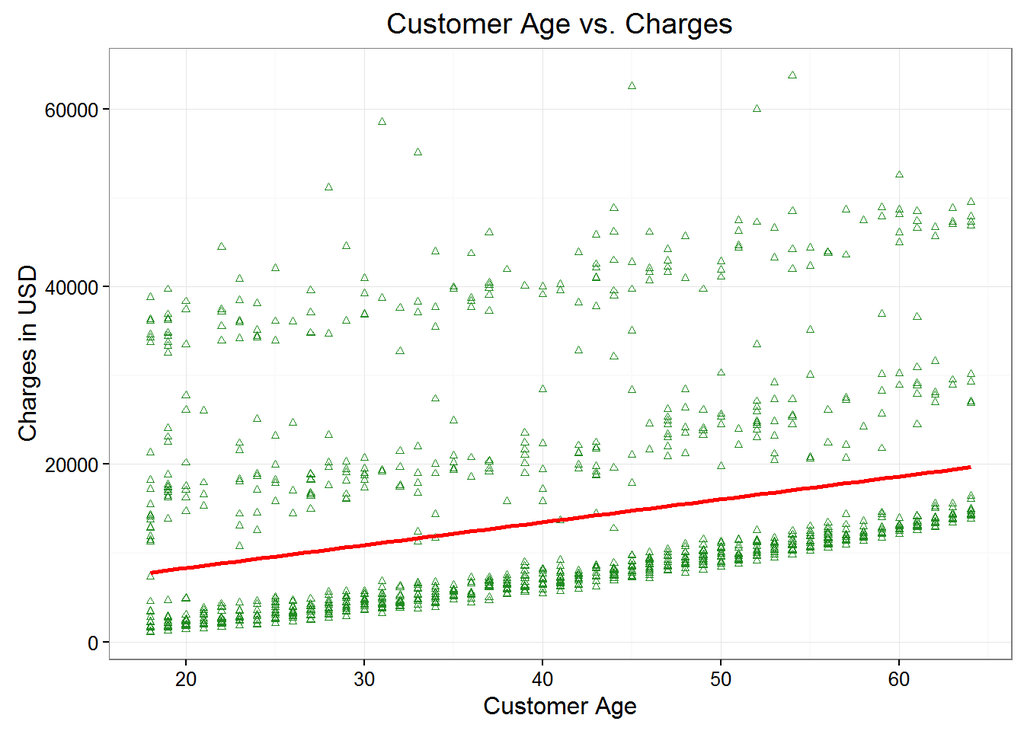

```r
insuranceData$obesity_category <- ifelse(insuranceData$bmi >= 30, 'yes', 'no')
insuranceData$obesity <- ifelse(insuranceData$bmi >= 30, 1, 0)

insuranceData$smokerFactor <- ifelse(insuranceData$smoker=='yes', 1, 0)

insuranceData$obesity_smoker <- insuranceData$obesity*insuranceData$smokerFactor
insuranceData$obesity_smoker_category <- ifelse(insuranceData$obesity_smoker == 1, 'yes', 'no')

library(ggplot2)
ggplot(insuranceData, aes(x = age, y = charges)) +
  geom_point(color = "forestgreen", shape=2, size = 1) + theme_bw() +
  stat_smooth(method = "lm", col = "red", se=FALSE) +
  xlab("Customer Age") + ylab("Charges in USD") +
  ggtitle("Customer Age vs. Charges")
```

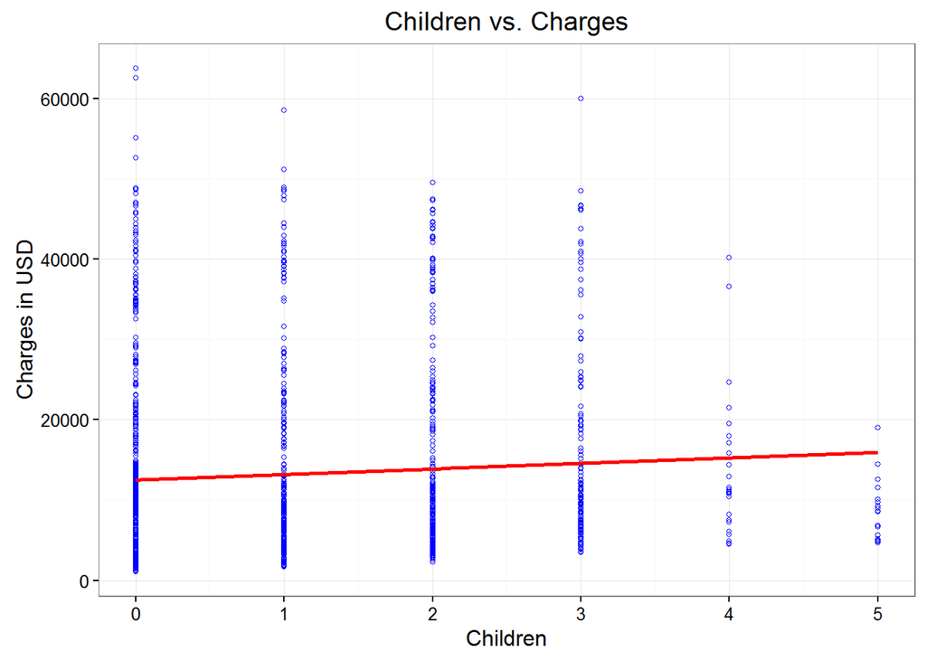

```r
ggplot(insuranceData, aes(x = children, y = charges)) +
  geom_point(color = "blue", shape=1, size = 1) + theme_bw() +
  stat_smooth(method = "lm", col = "red", se=FALSE) +
  xlab("Children") + ylab("Charges in USD") +
  ggtitle("Children vs. Charges")
```

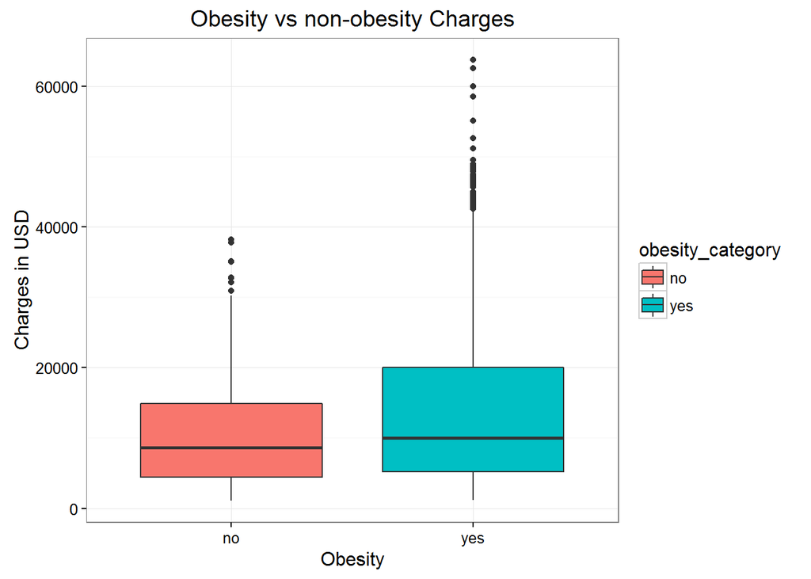

```r
ggplot(insuranceData, aes(fill = obesity_category, factor(obesity_category), charges)) +
  geom_boxplot() + theme_bw() + xlab("Obesity") + ylab("Charges in USD") +
  ggtitle("Obesity vs non-obesity Charges")
```

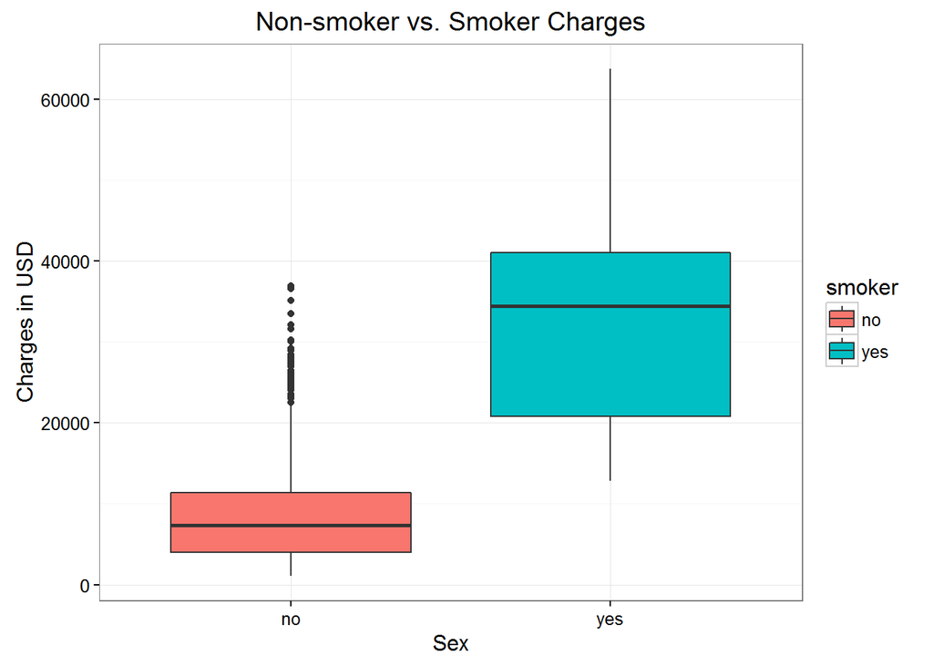

```r
ggplot(insuranceData, aes(fill = smoker, factor(smoker), charges)) +
  geom_boxplot() + theme_bw() + xlab("Sex") + ylab("Charges in USD") +
  ggtitle("Non-smoker vs. Smoker Charges")
```

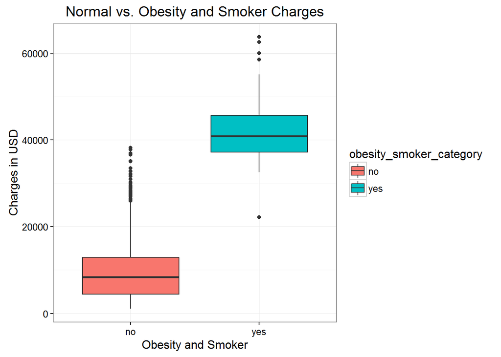

```r
ggplot(insuranceData, aes(fill = obesity_smoker_category, factor(obesity_smoker_category), charges)) +
  geom_boxplot() + theme_bw() + xlab("Obesity and Smoker") + ylab("Charges in USD") +
  ggtitle("Normal vs. Obesity and Smoker Charges")
```

### The VP has six questions for you to answer:

#### 1. Which demographic and geographic variables explain medical charges of the 1,338 customers in the insurance.csv file? How do you know? What are the effects of these identified variables on medical charges?

Age, bmi, children, smoker. Those variables all have very small p-value (99.9% confidence).

```r
insuranceFullModel<-lm(charges~.,data=insuranceData)
summary(insuranceFullModel)
```

```
##
## Call:
## lm(formula = charges ~ ., data = insuranceData)
##
## Residuals:
##      Min       1Q   Median       3Q      Max
## -18234.3  -1826.1  -1251.6   -447.5  24803.9
##
## Coefficients: (3 not defined because of singularities)
##                             Estimate Std. Error t value
## (Intercept)                -4745.546    959.685  -4.945
## age                          263.242      8.805  29.897
## sexmale                     -491.179    246.563  -1.992
## bmi                          115.035     34.560   3.329
## children                     520.402    101.958   5.104
## smokeryes                  13402.363    443.910  30.192
## regionnorthwest             -266.836    352.410  -0.757
## regionsoutheast             -825.000    354.800  -2.325
## regionsouthwest            -1224.315    353.684  -3.462
## obesity_categoryyes         -865.057    425.775  -2.032
## obesity                           NA         NA      NA
## smokerFactor                      NA         NA      NA
## obesity_smoker             19794.852    610.092  32.446
## obesity_smoker_categoryyes        NA         NA      NA
##                                        Pr(>|t|)
## (Intercept)                         0.000000859 ***
## age                        < 0.0000000000000002 ***
## sexmale                                0.046565 *
## bmi                                    0.000897 ***
## children                            0.000000381 ***
## smokeryes                  < 0.0000000000000002 ***
## regionnorthwest                        0.449079
## regionsoutheast                        0.020209 *
## regionsouthwest                        0.000554 ***
## obesity_categoryyes                    0.042381 *
## obesity                                      NA
## smokerFactor                                 NA
## obesity_smoker             < 0.0000000000000002 ***
## obesity_smoker_categoryyes                   NA
## ---
## Signif. codes:  0 '***' 0.001 '**' 0.01 '*' 0.05 '.' 0.1 ' ' 1
##
## Residual standard error: 4485 on 1327 degrees of freedom
## Multiple R-squared:  0.8639, Adjusted R-squared:  0.8628
## F-statistic: 842.1 on 10 and 1327 DF,  p-value: < 0.00000000000000022
```

If we remove insignificant terms sex and region.

$Charges = -12102.77 + 257.85 *age + 321.85 * bmi + 473.50 * children + 23811.40 * smoker$

```r
reducedInsuranceModel <- lm(charges~ age+bmi+children+smoker,data=insuranceData)
summary(reducedInsuranceModel)
```

```
##
## Call:
## lm(formula = charges ~ age + bmi + children + smoker, data = insuranceData)
##
## Residuals:
##      Min       1Q   Median       3Q      Max
## -11897.9  -2920.8   -986.6   1392.2  29509.6
##
## Coefficients:
##              Estimate Std. Error t value             Pr(>|t|)
## (Intercept) -12102.77     941.98 -12.848 < 0.0000000000000002 ***
## age            257.85      11.90  21.675 < 0.0000000000000002 ***
## bmi            321.85      27.38  11.756 < 0.0000000000000002 ***
## children       473.50     137.79   3.436             0.000608 ***
## smokeryes    23811.40     411.22  57.904 < 0.0000000000000002 ***
## ---
## Signif. codes:  0 '***' 0.001 '**' 0.01 '*' 0.05 '.' 0.1 ' ' 1
##
## Residual standard error: 6068 on 1333 degrees of freedom
## Multiple R-squared:  0.7497, Adjusted R-squared:  0.7489
## F-statistic: 998.1 on 4 and 1333 DF,  p-value: < 0.00000000000000022
```

#### 2. The World Health Organization (WHO) defined an obese person as someone who has a BMI ≥ 30. What is the effect of obesity on medical charges? [Hint: You will need to use the specified model in Question 1 and add in a dummy variable to account for the effect of obesity.]

Obesity (bmi >= 30) increases medical charges by 2904.47.

$Charges = -7816.28 + 258.03 *age + 131.71 * bmi + 473.87 * children + 23819.41 * smoker + 2904.47 * obesity$

```r
insuranceData$obesity <- (ifelse(insuranceData$bmi >= 30, 1, 0))
insuranceModel2 <- lm(charges~age+bmi+children+smoker+obesity, data=insuranceData)
summary(insuranceModel2)
```

```
##
## Call:
## lm(formula = charges ~ age + bmi + children + smoker + obesity,
##     data = insuranceData)
##
## Residuals:
##    Min     1Q Median     3Q    Max
## -12530  -3503   -232   1494  28075
##
## Coefficients:
##             Estimate Std. Error t value             Pr(>|t|)
## (Intercept) -7816.28    1233.73  -6.335       0.000000000323 ***
## age           258.03      11.78  21.909 < 0.0000000000000002 ***
## bmi           131.71      44.93   2.932             0.003428 **
## children      473.87     136.41   3.474             0.000529 ***
## smokeryes   23819.41     407.10  58.511 < 0.0000000000000002 ***
## obesity      2904.47     547.33   5.307       0.000000130664 ***
## ---
## Signif. codes:  0 '***' 0.001 '**' 0.01 '*' 0.05 '.' 0.1 ' ' 1
##
## Residual standard error: 6007 on 1332 degrees of freedom
## Multiple R-squared:  0.7549, Adjusted R-squared:  0.754
## F-statistic: 820.4 on 5 and 1332 DF,  p-value: < 0.00000000000000022
```

#### 3. What is the effect on medical charges of someone who is both obese and a smoker? [Hint: You will need to use the specified model in Question 2 and add in an interaction term to account for obesity and smoking.]

Obseity and smoker increases medical charges by 19684.869.

```r
insuranceData$smokerFactor <- (ifelse(insuranceData$smoker=='yes', 1, 0))
insuranceData$obesity_smoker <- (insuranceData$obesity*insuranceData$smokerFactor)
library(knitr)
Numeric_Vars <-insuranceData[,c('age','bmi','children','smokerFactor','obesity_smoker','charges')]
Correlation_Matrix <- cor(Numeric_Vars)
kable(Correlation_Matrix)
```

|  | age | bmi | children | smokerFactor | obesity_smoker | charges |
| --- | --- | --- | --- | --- | --- | --- |
| age | 1.0000000 | 0.1092719 | 0.0424690 | -0.0250188 | -0.0020575 | 0.2990082 |
| bmi | 0.1092719 | 1.0000000 | 0.0127589 | 0.0037504 | 0.2769814 | 0.1983410 |
| children | 0.0424690 | 0.0127589 | 1.0000000 | 0.0076731 | 0.0004727 | 0.0679982 |
| smokerFactor | -0.0250188 | 0.0037504 | 0.0076731 | 1.0000000 | 0.6870041 | 0.7872514 |
| obesity_smoker | -0.0020575 | 0.2769814 | 0.0004727 | 0.6870041 | 1.0000000 | 0.8146615 |
| charges | 0.2990082 | 0.1983410 | 0.0679982 | 0.7872514 | 0.8146615 | 1.0000000 |

```r
insuranceModel3 <- lm(charges~age+bmi+children+smoker+obesity+obesity_smoker, data=insuranceData)
summary(insuranceModel3)
```

```
##
## Call:
## lm(formula = charges ~ age + bmi + children + smoker + obesity +
##     obesity_smoker, data = insuranceData)
##
## Residuals:
##      Min       1Q   Median       3Q      Max
## -19074.0  -1865.8  -1254.9   -440.4  24385.3
##
## Coefficients:
##                 Estimate Std. Error t value             Pr(>|t|)
## (Intercept)    -5097.881    929.887  -5.482         0.0000000502 ***
## age              264.226      8.842  29.883 < 0.0000000000000002 ***
## bmi               97.698     33.738   2.896              0.00384 **
## children         512.424    102.395   5.004         0.0000006354 ***
## smokeryes      13412.395    445.186  30.128 < 0.0000000000000002 ***
## obesity         -809.791    426.763  -1.898              0.05798 .
## obesity_smoker 19684.869    612.394  32.144 < 0.0000000000000002 ***
## ---
## Signif. codes:  0 '***' 0.001 '**' 0.01 '*' 0.05 '.' 0.1 ' ' 1
##
## Residual standard error: 4509 on 1331 degrees of freedom
## Multiple R-squared:  0.862,  Adjusted R-squared:  0.8614
## F-statistic:  1386 on 6 and 1331 DF,  p-value: < 0.00000000000000022
```

#### 4. Can you recommend a preferred model Health KC should use to predict medical charges of potential customers? How much variation in the Insurance dataset is explained by the preferred model? [Hint: You will need to conduct partial F-tests to compare the three models created to answer Questions 1, 2, and 3.]

We can say the model three with obesity smoker is the preferred model.

```r
anova(reducedInsuranceModel, insuranceModel2)
```

```
## Analysis of Variance Table
##
## Model 1: charges ~ age + bmi + children + smoker
## Model 2: charges ~ age + bmi + children + smoker + obesity
##   Res.Df         RSS Df  Sum of Sq     F       Pr(>F)
## 1   1333 49078450117
## 2   1332 48062344964  1 1016105153 28.16 0.0000001307 ***
## ---
## Signif. codes:  0 '***' 0.001 '**' 0.01 '*' 0.05 '.' 0.1 ' ' 1
```

```r
anova(insuranceModel2, insuranceModel3)
```

```
## Analysis of Variance Table
##
## Model 1: charges ~ age + bmi + children + smoker + obesity
## Model 2: charges ~ age + bmi + children + smoker + obesity + obesity_smoker
##   Res.Df         RSS Df   Sum of Sq      F                Pr(>F)
## 1   1332 48062344964
## 2   1331 27057694816  1 21004650148 1033.2 < 0.00000000000000022 ***
## ---
## Signif. codes:  0 '***' 0.001 '**' 0.01 '*' 0.05 '.' 0.1 ' ' 1
```

#### 5. Are there any known statistical problem(s) with the chosen model? [Hint: You will need to examine the four linear regression assumptions plus multicollinearity.] If there are known problem(s), what are your recommendation(s) for mitigating them?

Normal Q-Q Plot-The plotted values should be a straight line. If it is curved (an S shape), then assumption #2 (normality of errors) is violated. This means data has more extreme value than would be expected if they truly came from a Normal distribution. The higher medical charges values is not a truely normal distribution.

Scale-Location Plot-This plot is a repeat of the Residuals vs. Fitted Plot but on a different scale. The square root of the standardized residuals are plotted against the fitted values. The standardized residuals should look random. If there is a pattern the values are most positive assumption #3 (homoskedasticity) is violated.

Residuals vs. Leverage-This plot highlights the outlier values of the target variable (Y) that have the highest effect on the parameter estimates. These are called “high influence” points. Look for values outside of the Cook’s distance (red dashed line). There are many outliers above the Cook’s distance line. There are one single outlier far below Cook’s distance line.

The recommendations are to remove outlier charges, gather three times more rows from vif test. We also need more variables that can explain the higher charges.

```r
library(ggfortify)
```

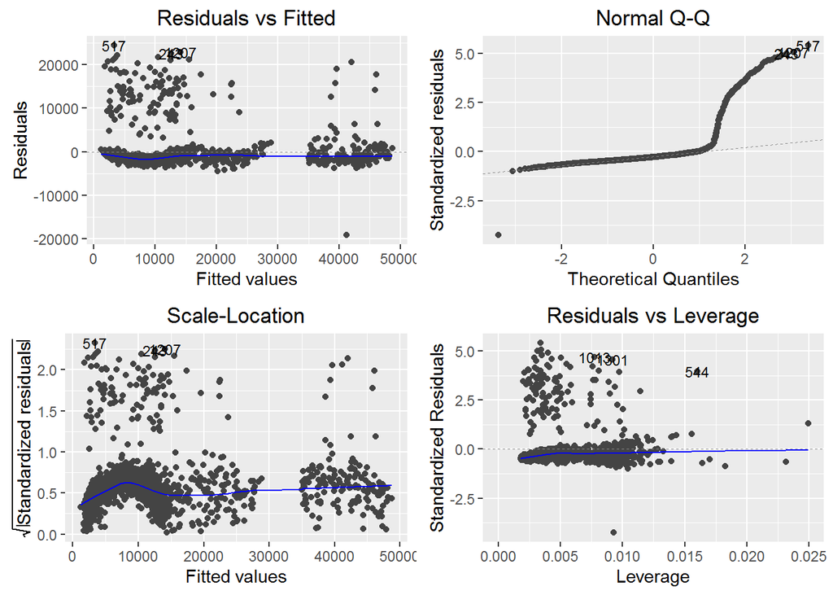

```r
autoplot(insuranceModel3, label.size = 3)
```

Multicollinearity Use variance inflation factor (VIF) for each predictors Here obesity is close to 3 which means some autocorrelation. We need a sample size three times as large as your current sample size to overcome the multicollinearity in the model.

```r
library(car)
vif(insuranceModel3)
```

```
##            age            bmi       children         smoker        obesity
##       1.014989       2.783933       1.002087       2.124258       2.987120
## obesity_smoker
##       2.385075
```

No Autocorrelation Use Durbin Watson statistic. DW statistic close to 2 means there is no autocorrelation. Closer to 0 means positive autocorrelation. Closer to 4 means negative autocorrelation. Here value is 2.05 so we can say there is no autocorrelation.

```r
durbinWatsonTest(insuranceModel3)
```

```
##  lag Autocorrelation D-W Statistic p-value
##    1     -0.02961429      2.059074   0.268
##  Alternative hypothesis: rho != 0
```

Homoskedasticity The probability distribution of the errors has constant variance. P-value is slightly above 0.05 so we cannot rule out heteroscedasticity.

```r
ncvTest(insuranceModel3)
```

```
## Non-constant Variance Score Test
## Variance formula: ~ fitted.values
## Chisquare = 3.787985    Df = 1     p = 0.05162175
```

#### 6. The VP gives you a batch file called CompanyABC.csv, which contains demographic information of 50 potential customers at a small business. All 50 employees are scattered across the eastern U.S. seaboard. Use the preferred model to predict medical charges of the 50 potential customers in the CompanyABC.csv batch file. She does not want to see predicted charges for all 50 customers. The VP only wants the predictions summarized at a high level for ease of communications with other managers at Health KC. [Hint: You should create a new variable in your data frame for the predicted charges. Something simple like “estimated_charges” is sufficient. You will then perform exploratory data analysis of “estimated_charges” to examine the 50 predicted charges.]

The estimated mean charge is 12181 per customer. The estimate median charge is 10436. The estimated minimum charge is 1791. The estimated maximum charge is 47264.

```r
testingData<-read.csv(file="C:/Users/lj015625/Desktop/DataMining Class/Applied_Data_Mining/assignment_module_1/data/CompanyABC.csv")
testingData$obesity <- ifelse(testingData$bmi >= 30, 1, 0)
testingData$obesity_category <- ifelse(testingData$bmi >= 30, 'yes', 'no')
testingData$smokerFactor <- ifelse(testingData$smoker=='yes', 1, 0)
testingData$obesity_smoker <- testingData$obesity*testingData$smokerFactor
testingData$obesity_smoker_category <- ifelse(testingData$obesity_smoker == 1, 'yes', 'no')
summary(testingData)
```

```
##        region       sex          bmi           children    smoker
##  northeast:13   female:25   Min.   :17.77   Min.   :0.00   no :38
##  northwest:13   male  :25   1st Qu.:27.25   1st Qu.:0.00   yes:12
##  southeast:11               Median :29.34   Median :0.50
##  southwest:13               Mean   :29.88   Mean   :0.98
##                             3rd Qu.:33.34   3rd Qu.:2.00
##                             Max.   :49.06   Max.   :3.00
##       age           obesity     obesity_category    smokerFactor
##  Min.   :18.00   Min.   :0.00   Length:50          Min.   :0.00
##  1st Qu.:23.00   1st Qu.:0.00   Class :character   1st Qu.:0.00
##  Median :34.00   Median :0.00   Mode  :character   Median :0.00
##  Mean   :37.14   Mean   :0.44                      Mean   :0.24
##  3rd Qu.:51.75   3rd Qu.:1.00                      3rd Qu.:0.00
##  Max.   :63.00   Max.   :1.00                      Max.   :1.00
##  obesity_smoker obesity_smoker_category
##  Min.   :0.00   Length:50
##  1st Qu.:0.00   Class :character
##  Median :0.00   Mode  :character
##  Mean   :0.06
##  3rd Qu.:0.00
##  Max.   :1.00
```

```r
testingData$estimated_charges <- predict(insuranceModel3, testingData)
summary(testingData$estimated_charges)
```

```
##    Min. 1st Qu.  Median    Mean 3rd Qu.    Max.
##    1791    4737   10440   12180   14050   47260
```

A smoker or an obesity customer have higher estimate charges. Both smoker and obesity customer have far higher estimate charges due to interaction term from smoker and obesity.

```r
aggregate(estimated_charges~smoker, data=testingData, FUN="mean")
```

```
##   smoker estimated_charges
## 1     no          7585.697
## 2    yes         26731.957
```

```r
aggregate(estimated_charges~obesity, data=testingData, FUN="mean")
```

```
##   obesity estimated_charges
## 1       0          11251.83
## 2       1          13363.12
```

```r
# interaction term
aggregate(estimated_charges~obesity_smoker, data=testingData, FUN="mean")
```

```
##   obesity_smoker estimated_charges
## 1              0          10117.55
## 2              1          44505.10
```

ggplot helps visualize data much better than tables.

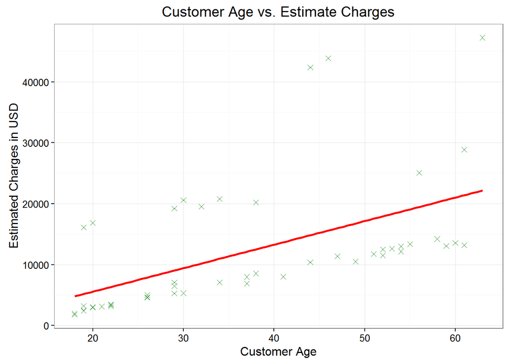

```r
library(ggplot2)
ggplot(testingData, aes(x = age, y = estimated_charges)) +
  geom_point(color = "forestgreen", shape=4, size = 2) + theme_bw() +
  stat_smooth(method = "lm", col = "red", se=FALSE) +
  xlab("Customer Age") + ylab("Estimated Charges in USD") +
  ggtitle("Customer Age vs. Estimate Charges")
```

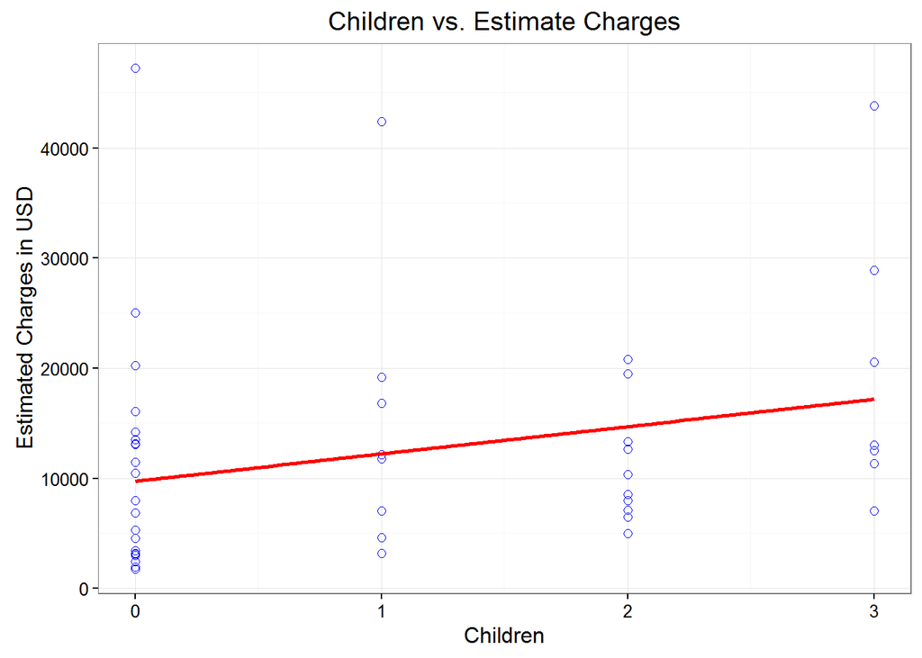

```r
ggplot(testingData, aes(x = children, y = estimated_charges)) +
  geom_point(color = "blue", shape=1, size = 2) + theme_bw() +
  stat_smooth(method = "lm", col = "red", se=FALSE) +
  xlab("Children") + ylab("Estimated Charges in USD") +
  ggtitle("Children vs. Estimate Charges")
```

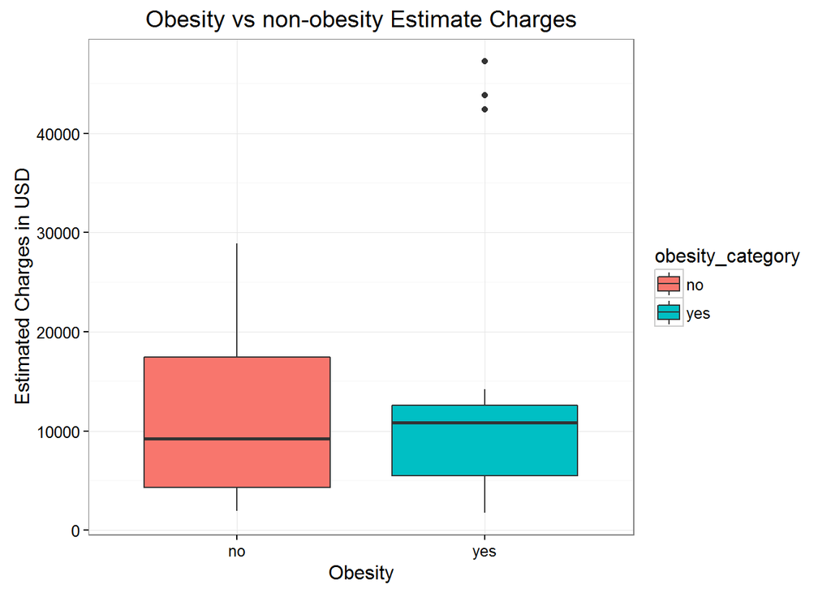

```r
ggplot(testingData, aes(fill = obesity_category, factor(obesity_category), estimated_charges)) +
  geom_boxplot() + theme_bw() + xlab("Obesity") + ylab("Estimated Charges in USD") +
  ggtitle("Obesity vs non-obesity Estimate Charges")
```

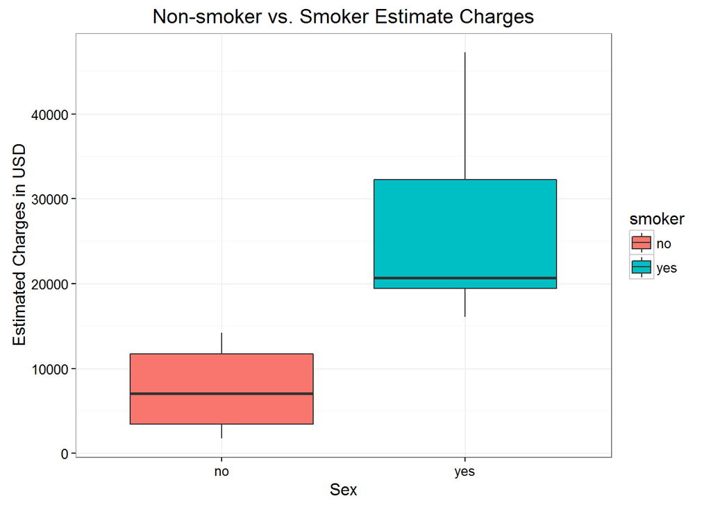

```r
ggplot(testingData, aes(fill = smoker, factor(smoker), estimated_charges)) +
  geom_boxplot() + theme_bw() + xlab("Sex") + ylab("Estimated Charges in USD") +
  ggtitle("Non-smoker vs. Smoker Estimate Charges")
```

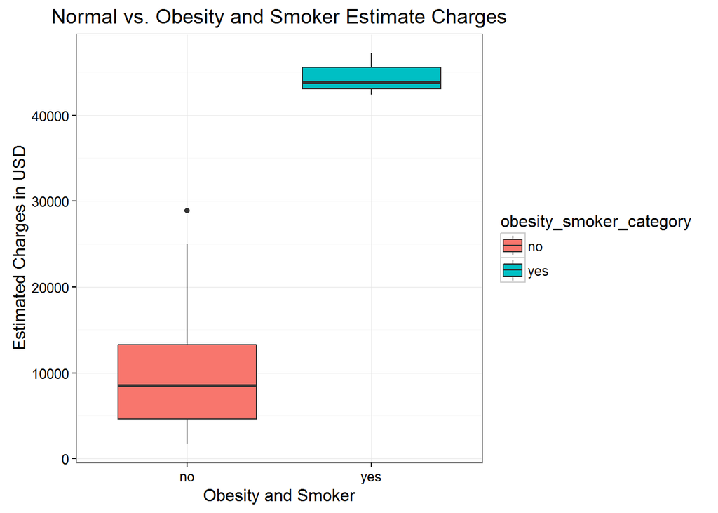

```r
ggplot(testingData, aes(fill = obesity_smoker_category, factor(obesity_smoker_category), estimated_charges)) +
  geom_boxplot() + theme_bw() + xlab("Obesity and Smoker") + ylab("Estimated Charges in USD") +
  ggtitle("Normal vs. Obesity and Smoker Estimate Charges")
```

End